# Dream Home/Investment

# Total rooms above ground

```r
homedf$TotRmsAbvGrd <-as.factor(homedf$TotRmsAbvGrd)
```

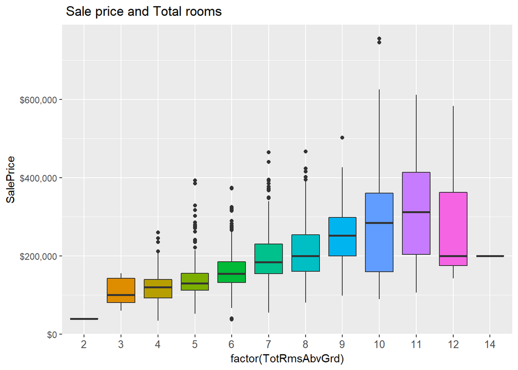

```r
ggplot(homedf, aes(x = factor(TotRmsAbvGrd), y = SalePrice, fill = factor(TotRmsAbvGrd))) +
  geom_boxplot() +
  scale_y_continuous(labels = dollar)+
  theme(axis.text.x = element_text(angle = 0, size = 10), legend.position = "none")+
  ggtitle( " Sale price and Total rooms")
```

The bigger the place the better the value

# Fireplace

```r
table(homedf$Fireplaces)
```

```
##
##   0   1   2   3
## 690 650 115   5
```

```r
table(homedf$FireplaceQu)
```

```
##
##           Ex           Fa           Gd No Fireplace           Po
##           24           33          380          690           20
##           TA
##          313
```

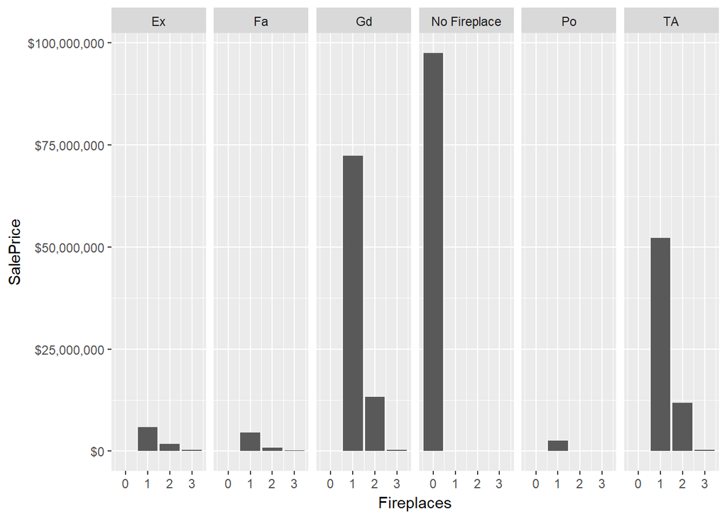

```r
ggplot(homedf, aes(x = Fireplaces, y = SalePrice)) +
  geom_bar(stat = "identity")+
   scale_y_continuous(labels = dollar)+
  facet_grid(~FireplaceQu)
```

# Garage

7 total variables related to the home’s garage. GarageType, GarageYrBlt, GarageFinish,GarageQual,GarageCond contain 81 missing values.

# Checking to see the homes built with no garage or it’s missing the data.

```r
homedf %>% count(homedf$GarageArea == 0)
```

```
## # A tibble: 2 x 2
##   `homedf$GarageArea == 0`     n
##   <lgl>                    <int>
## 1 F                         1379
## 2 T                           81
```

```r
table(homedf$GarageCars)
```

```
##
##   0   1   2   3   4
##  81 369 824 181   5
```

81 records in GarageArea andGarageCars shows 0. We assume the homes built without a garage.

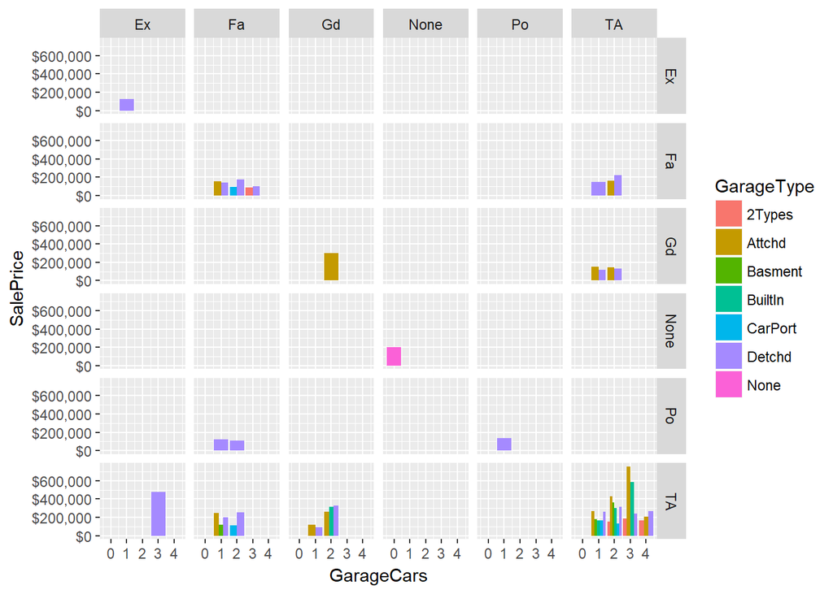

```r
ggplot(homedf, aes(fill=GarageType, y=SalePrice, x=GarageCars)) +
geom_bar(position = "dodge", stat="identity")+
   scale_y_continuous(labels = dollar)+
facet_grid(GarageCond ~GarageQual)
```

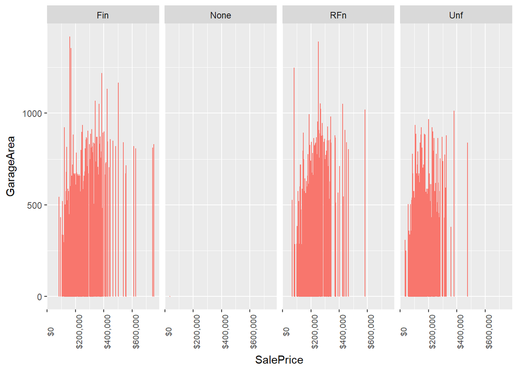

```r
ggplot(homedf, aes( y=GarageArea, x= SalePrice,colour='red')) +
geom_bar(stat = "identity", position ="dodge")+
   scale_x_continuous(labels = dollar)+
   theme(axis.text.x = element_text(angle = 90, size = 8), legend.position = "none")+
facet_grid(~GarageFinish)
```

A spacious and finished garage adds value to home

# porch and Deck

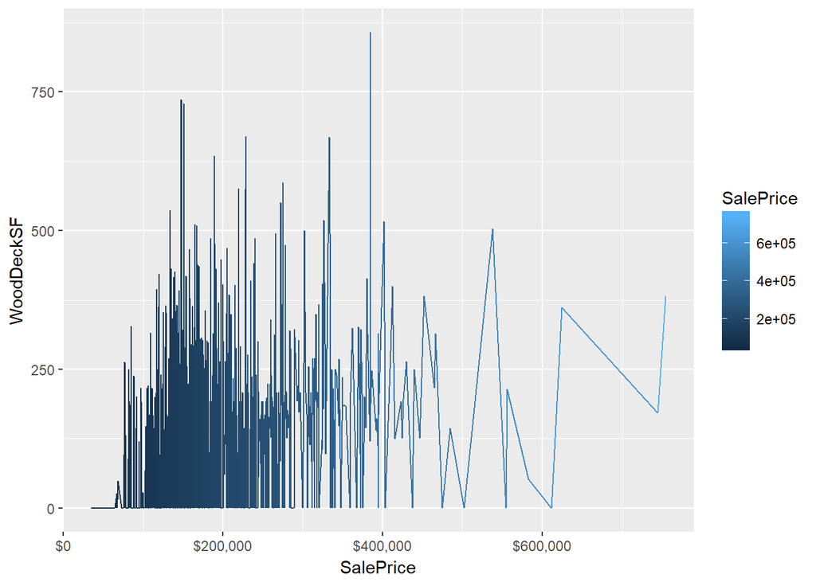

```r
ggplot(homedf,aes(SalePrice,WoodDeckSF,color=SalePrice))+
  geom_line()+
  scale_x_continuous(labels=dollar)
```

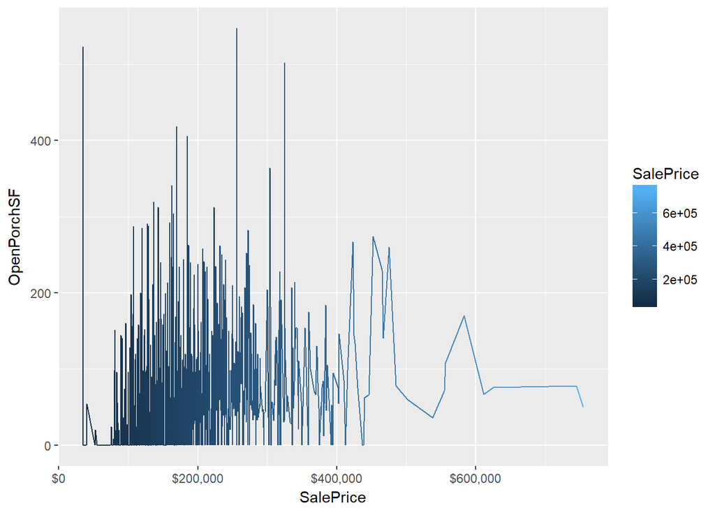

```r
ggplot(homedf,aes(SalePrice,OpenPorchSF,color=SalePrice))+
  geom_line()+
  scale_x_continuous(labels=dollar)
```

# Sale type and condition

```r
  table(homedf$SaleCondition,homedf$SaleType)
```

```
##
##            COD  Con ConLD ConLI ConLw  CWD  New  Oth   WD
##   Abnorml   24    0     2     1     0    1    0    3   70
##   AdjLand    0    0     0     0     0    0    0    0    4
##   Alloca     0    0     0     0     0    0    0    0   12
##   Family     0    0     0     0     0    1    0    0   19
##   Normal    19    2     6     4     5    2    0    0 1160
##   Partial    0    0     1     0     0    0  122    0    2
```

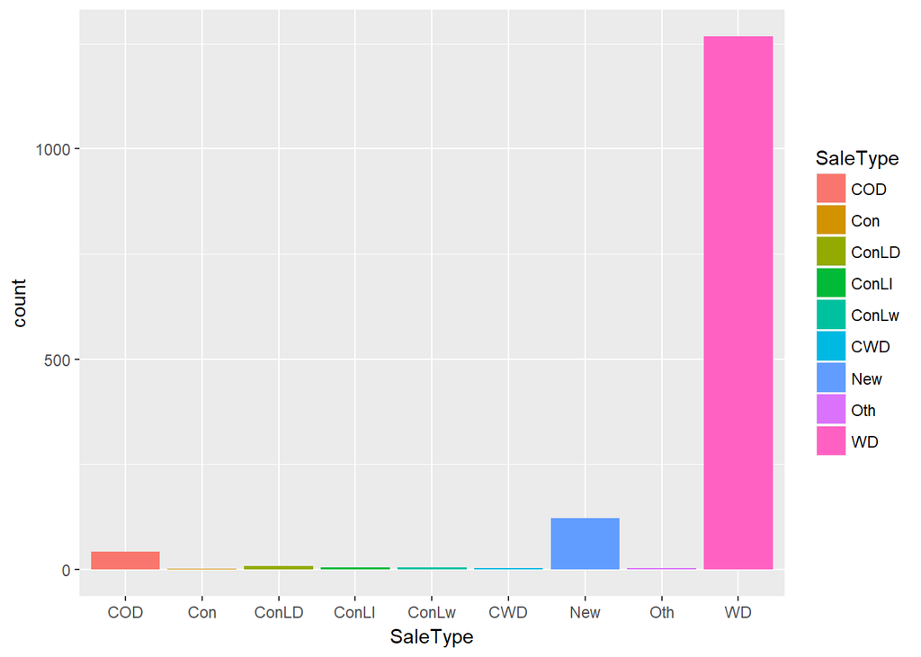

```r
ggplot(homedf, aes(SaleType,fill = SaleType))+
  geom_histogram(stat = "count")
```

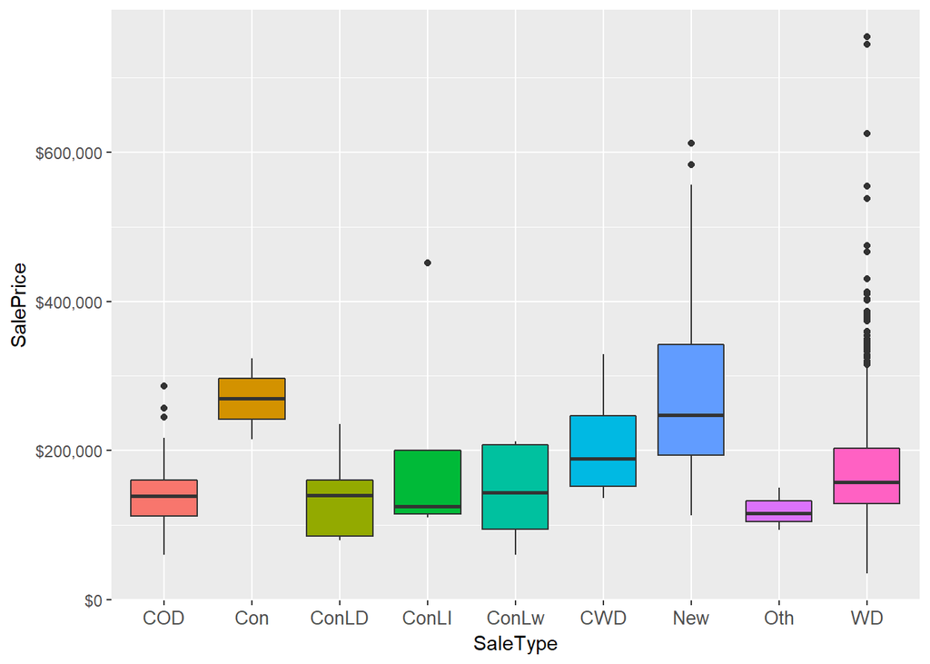

```r
# boxplot of saletype and sale price
ggplot(homedf, aes(x = SaleType, y = SalePrice)) +
  geom_boxplot(aes(fill = SaleType))+
  theme(axis.text.x = element_text(angle = 0, size = 10), legend.position = "none") +  scale_y_continuous(labels = dollar)
```

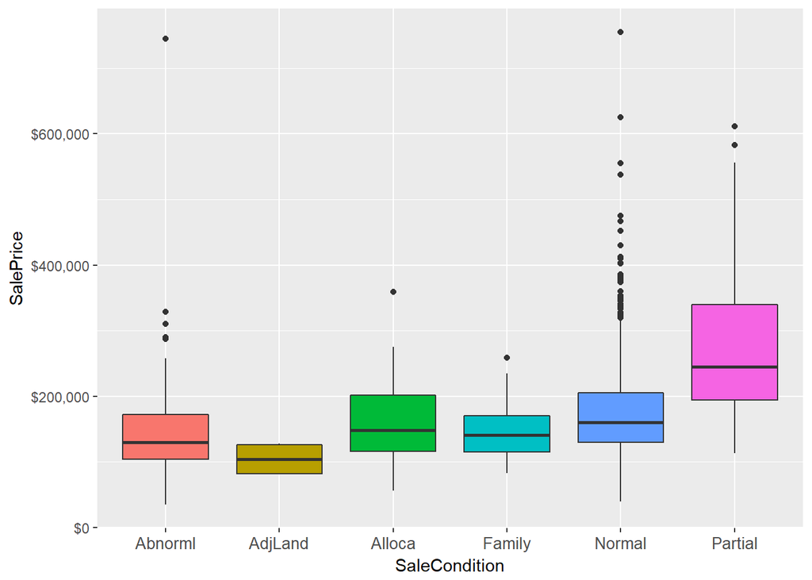

```r
# Boxplot of sale price Vs condition
ggplot(homedf, aes(x = SaleCondition, y = SalePrice)) +
  geom_boxplot(aes(fill = SaleCondition)) +
  theme(axis.text.x = element_text(angle = 0, size = 10), legend.position = "none") +
  scale_y_continuous(labels = dollar)
```

#Sale price Histogram

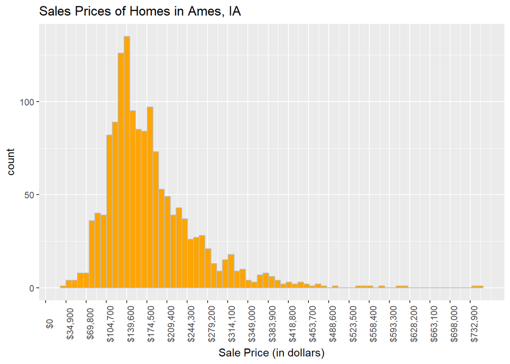

```r
ggplot( homedf, aes(x = SalePrice)) +
  geom_histogram(binwidth=10000, fill = "orange", color = "grey") +
  scale_x_continuous(labels = dollar, breaks = seq(0, 755000, 34900)) +
  theme(axis.text.x = element_text(angle = 90))+
  labs(x = "Sale Price (in dollars)") +
  ggtitle("Sales Prices of Homes in Ames, IA")
```

# Dropping outliers of sale price below and above 1st and 99th percentile

```r
# remove outliers
outlierMinMax <- quantile(homedf$saleprice, c(.01, .99))
df <- homedf[ homedf$saleprice > outlierMinMax[1] & homedf$saleprice < outlierMinMax[2],  ]
# end number of obs
end <- dim(df)[1]
```

```r
# obs and vars after cleaning
endObs <- dim(df)[1]
endVars <- dim(df)[2]
```